# M02-Introduction to Data Science in R-Reflection

Author

Nikolas Sahami

Published

September 8, 2026

# 1 Quick Summary of What I Learned

**NoteNote:**

I did not know much about reproducible data science or literate coding prior to this assignment, so most of the information was new for me.

## 1.1 Reproducible Data Science

One of the most important things I learned was that reproducible data science is very dependent on the organization and format of the projects. They should be organized so that someone else would be able to follow your steps exactly with minimal prior knowledge. One thing that stood out was the fact that data manipulation and cleanup should be done with code instead of through programs with a GUI, because the code creates a record of every step taken, and allows someone else to go in and manipulate the data in the exact same way you did.

## 1.2 Literate Coding

The other videos taught me about literate coding and how combining code with visuals and written explanations in a single file makes the information much easier to understand. Quarto is one of the best tools for this because a `.qmd` file allows you to include code chunks and their outputs with regular written text. I like this because it allows me to explain my process next to the code that is actually doing it. I also learned about Git and GitHub, and how they can be used to keep track of changes to files and allow me to go back to older versions of my work. It is also really interesting that Quarto can be published through GitHub Pages using commands in the terminal once I connect it to my account. For this file, I have already pushed my initial version to GitHub, and I will keep pushing my updates out, and then eventually publish it using the `gh-pages` command in the terminal.

# 2 Quarto

To me, the most impressive thing about Quarto is that it can run code chunks next to plain text when it renders the document, and since everything is written within the same source file, it can be exported in many different ways. We have only used the HTML format so far, but the fact that I could render this same file in a number of different formats makes it extremely versatile and I could see myself using it in the future. It could be rendered as:

- HTML
- A Word Document
- A PDF
- A presentation

For example, I can insert a code chunk directly below this paragraph and have it run whenever the page is rendered:

```r
x <- 5
y <- 16
x * y
```

```
[1] 80
```

**TipNote:**

Also in this code chunk, I used the code chunk option of `#| echo: true` to tell it to show the entire code instead of just the result. By inserting `#|` before, Quarto automatically knows to treat this as a code-cell option rather than part of the R code being executed.

Before starting on this module, I always assumed that the report writing and the actual coding were entirely separate processes, but Quarto lets me do it all together. I love the features that it provides, such as the callout I used above this and the different formatting options, especially in the YAML header, and I like that it can be edited through both the source code directly and the visual editor. While I have been trying to do this entire assignment through the Source panel, I like going back and forth with the Visual editor to see my edits more clearly and ensure everything is formatted the way I would like.

I could definitely see myself using Quarto for school, especially in classes that require large written reports with calculations. I am not sure if I would use it so much in my everyday career, but I could absolutely see its use in creating files or presentations where I need a combination of text, data, and visualizations. I also really like how easily editable everything is through the source code, and I can always re-render it quickly instead of manually rebuilding charts and trying to correctly format data in a service like Google Slides or PowerPoint.

# 3 The Reproducibility Crisis

One of the most important things I learned from the reproducibility crisis video was the difference between reproducibility and replicability. While I had heard both terms before, I probably would have used them interchangeably. The video explained the difference as:

**Reproducibility**

Reproducibility means obtaining the same computational results using the exact same input data, code, and analysis conditions.

**Replicability**

Replicability means getting consistent results through an independent study that collects its own data to investigate the same scientific question. It does not require the exact same steps to be followed

Another thing that stood out to me was how difficult it can be to recreate research, even when the original researcher is the one trying to do it. One of the statistics mentioned that nearly 90% of scientists surveyed believed there was either a significant or slight reproducibility crisis, and I found that pretty concerning.

Especially in marketing, where so much of the field relies on data to make decisions, being unable to reproduce someone else’s findings can be a big issue. Marketing research can involve surveys, customer data, advertising performance, sales information, and many other sources, so if someone only shares their final report or findings, it can often be very difficult for another person to determine exactly how they reached their conclusions. This can be a major problem when these results are being used to make important business decisions for a company.

Quarto is a great way to help address this issue because all the calculations and data manipulation can be put in the same file as the findings and written report. That way it can generate the results every time the document is rendered instead of having to rely on someone making important changes and transferring that final data to their report. Additionally, Git and GitHub can be very helpful in keeping track of the changes to a `.qmd` file over time, and being able to go back and restore previous versions. It is also very helpful that GitHub can directly publish webpages that anyone can access. This makes sharing the final report easier because it provides a way to distribute the final report without having to send different versions of the document back and forth.

# 4 Tidyverse and R

Tidyverse is one thing that I have had a bit of experience with before starting this module, so not all of the information was new to me. The main thing about Tidyverse is that it is actually a collection of other packages instead of just one. They are all designed to work together using a similar structure and syntax, and they allow for a lot of data formatting and cleaner observation, hence the name *tidy*-verse.

One new thing I learned was the actual concept of “tidy data”, where each variable has its own column, each observation has its own row, and each value has its own cell, making the data much easier to organize and manipulate.

The packages that stood out to me the most were `dplyr`, `tidyr`, and `ggplot2`. With `dplyr`, I can organize and manipulate the dataset using commands to filter rows, create variables, summarize data, and much more. `tidyr` can reshape messy data into a cleaner format, while `ggplot2` can turn that data into visualizations like graphs or scatterplots. The video also talked about the pipe tool `%>%` or `|>`, which we have also been covering in *IBM5910: Data Wrangling and Visualization*, and I like that it allows multiple operations to be written in sequence, as opposed to in a bunch of separate steps.

I learned that R can be used for almost the entire data analysis process, including importing data, cleaning and reorganizing it, performing calculations, summarizing results, and creating visualizations. Here is an example of that:

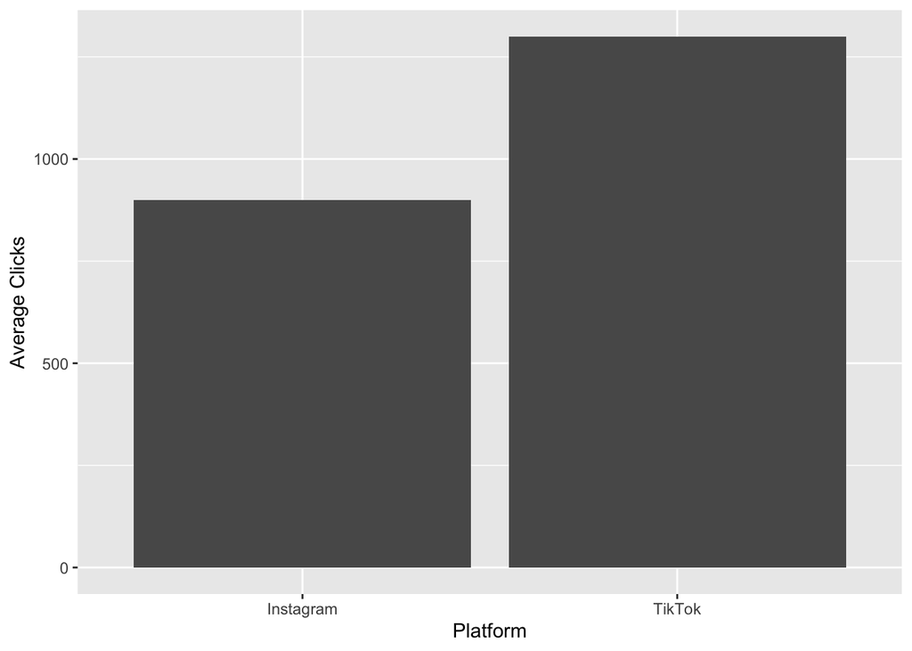

Figure 1: Average clicks by social media platform

```r
library(tidyverse)
# Create variables and data
campaigns <- data.frame(
  platform = c("Instagram", "Instagram", "TikTok", "TikTok"),
  clicks = c(800, 1000, 1200, 1400)
)

# group and summarize the data
campaign_summary <- campaigns |>
  group_by(platform) |>
  summarize(average_clicks = mean(clicks))

# Make a graph
ggplot(campaign_summary, aes(x = platform, y = average_clicks)) +
  geom_col() +
  labs(
    x = "Platform",
    y = "Average Clicks"
  )
```

Figure 1 is an example I created using fake data that shows how R can take information and immediately turn it into a visualization inside the same Quarto document, which is one of the reasons I can see it being useful for marketing analysis and reporting.

# 5 Two More Helpful Packages

## 5.1 `plotly`

The first package I think could be useful for my career is `plotly`. In marketing, presenting data in a way that is understandable to viewers can be just as important as analyzing it. I like that `plotly` can create interactive visualizations where users can hover over data points, zoom in, and explore the information themselves. Instead of putting several static graphs into a presentation, an interactive visualization would allow the viewer to explore the results that are most relevant to them

## 5.2 `shiny`

Another package that stood out to me was `shiny`, which allows R to create interactive web applications. I think this could be especially valuable in marketing because I could create something like a dashboard for campaign results where a user could choose which metric they want to examine. The person using the dashboard would not necessarily need to understand R or see the code behind it, which makes this even more useful in a business environment because the person making decisions from the data will not always be the one analyzing it.

# 6 R vs. Python

After watching all three videos ([Practitioner](https://www.youtube.com/watch?v=JAEs5IAhAYY), [Professor](https://www.youtube.com/watch?v=wWABGUGv-Bg), and [*Hello Quarto*](https://www.youtube.com/watch?v=p7Hxu4coDl8&t=1717s)), I think my biggest takeaway is that it is a pretty subjective argument and mainly depends on which one the user is most comfortable with and what they are trying to accomplish. **R** seems especially strong for statistics, data analysis, and visualization, while **Python** is a more general-purpose programming language that can also be used for things like software development and automation. Since I am currently doing more data analysis and visualization work, I think using **R** makes sense for me. That being said, I would definitely be open to learning **Python** in the future as it sounds like a great skill to have. The professor from University of Michigan also mentioned that there is no perfect programming language and that learning the concepts for your first language makes learning another one much easier, so I think they should be treated less as competitors and more just as different tools for different tasks.

The *Hello Quarto* video also showed that people using different languages can still contribute to the same project. One team member could work primarily in **R** and **RStudio** while another could use **Python** and **Jupyter**, and Quarto can handle the different code execution engines to produce a consistent final product. They can then use tools like GitHub to contribute their work to the same shared project. This is really interesting to me because it makes the debate much simpler and shows that people can use the tools they are most comfortable with or that are best suited for their particular task without having to make any big changes.

# 7 Appendix

Link to final web page on GitHub Pages:

https://itsnik1.github.io/m02-intro-data-science-in-r/

Link to GitHub Repository:

https://github.com/itsnik1/m02-intro-data-science-in-r

**ImportantNote:**

This appendix was added after I published, so I do not think it will show up on the final web page